# AP-4209 ESIEE-Paris: 2023 -2024

Projet 3 : Classification bayésienne et analyse factorielle discriminante

Adrien LINDEBERG – Théo LINDQVIST  
ESIEE Paris - DSIA

Le jeu de données contient des informations sur les thèses de doctorat françaises, en mettant l’accent sur la similarité sémantique. Cela représente un défi unique pour la classification en raison de la nature textuelle et sémantique des données. Mettre en place une classification bayésienne avancée avec analyse discriminante sur un jeu de données.

Introduction : Nous développerons un projet qui nous permettra de réutiliser tout ce que l’on a vu dans le cours. On mettra en place une classification bayésienne avancée avec analyse discriminante sur un jeu de données de résumés de thèses de doctorat françaises afin de les catégoriser en domaines d’étude ([Doctorat Dataset](https://www.kaggle.com/code/antoinebourgois2/4-french-doctoral-theses-semantic-search-tool?scriptVersionId=152132372)). Notre dataset possède huit colonnes:

- url: url de la thèse doctorat
- title: titre de la thèse du doctorat
- author : auteur de la thèse
- description : description du thème de la thèse
- direction: directeur de la thèse
- domain: domaine d’étude de la thèse
- status: statut de la thèse
- date: date de validation de la thèse

L’objectif sera de catégoriser nos données selon le domaine d’étude grâce à la recherche de similarité sémantique dans nos données.

Objectif principal : Mettre en place une classification bayésienne avancée avec analyse discriminante sur un jeu de données de résumés de thèses de doctorat françaises afin de les catégoriser en domaines d’étude.

## 1. Prétraitement des données :

Nous allons explorer notre dataset afin de mieux comprendre la manière dont il est construit et mieux préparer le prétraitement des données.

On n’oublie pas d’abord d’effacer toutes les variables en mémoire:

```r
rm(list = ls())

gc()
```

```
##          used (Mb) gc trigger (Mb) max used (Mb)
## Ncells 524439 28.1    1168205 62.4   660382 35.3
## Vcells 960887  7.4    8388608 64.0  1770407 13.6
```

On charge les packages nécessaires :

```r
library(ggplot2)
library(lattice)
library(kableExtra)
library(caret)
library(tidyverse)
library(stringr)
library(text)
library(tidytext)
library(textstem)
library(koRpus)
library(tm)
library(reshape2)
library(wordcloud)
library(syuzhet)
library(lubridate)
library(scales)
library(MASS)
library(naivebayes)
library(e1071)
library(SnowballC)
```

#### 1.1 Nettoyage du texte:

###### 1.1.1 Visualisation des données :

Dans un premier temps, nous chargeons le dataset qui contient les thèses de doctorat françaises. Puis nous réduisons la taille du dataset à 15 000 échantillons sélectionnés aléatoirement pour diminuer les temps d’entraînement du modèle tout en assurant la reproductibilité du modèle grâce à set.seed(42).

Nous nettoyons aussi les données en remplaçant les valeurs manquantes dans la colonne Description par des chaînes vides et complétons la colonne URL afin de générer des URLs complètes en y ajoutant un préfixe.

```r
df <- read.csv("french_thesis_20231021_metadata.csv")

#on réduit le nombre d'échantillons car il est beaucoup trop volumineux et cause des temps de run trop long
set.seed(42)
df <- df[sample(nrow(df), 15000, replace = FALSE), , drop = FALSE]

df$Description[is.na(df$Description)] <- ""
df$URL <- paste0("https://www.theses.fr/", df$URL)

df %>%
  head(3) %>%
  kbl() %>%
  kable_styling(bootstrap_options = "striped", full_width = FALSE,
                position = "center")
```

|  | URL | Title | Author | Description | Direction | Domain | Statuts | Date |
| --- | --- | --- | --- | --- | --- | --- | --- | --- |
| 61413 | https://www.theses.fr/1991BOR23090 | Les ruptures utérines : à propos de 21 cas observés à la maternité B, de 1980 à 1991 | Christine Vilbas |  | [(‘Jacques Horovitz’, ‘122096118’)] | Médecine | Soutenue | 1991-01-01 |
| 54425 | https://www.theses.fr/1991TOU30090 | Les sulfures océaniques : étude minéralogique et géochimique des processus hydrothermaux actuels et fossiles | Elisabeth Oudin | Les ressources chaudes (t350c) qui debouchent dans les vallees axiales des rides medio-oceaniques du pacifique ouest ou de l’atlantique forment des amas et des cheminees ou predominent les sulfures de… | [(‘Francis Tollon’, ‘077270460’)] | Minéralogie | Soutenue | 1991-01-01 |
| 99556 | https://www.theses.fr/1994TOU30239 | Calcul du transfert radiatif dans les plasmas thermiques : applications aux arcs dans les mélanges d’hexafluorure de soufre et de cuivre | Gilles Raynal | Cette etude porte sur la determination de la puissance rayonnee dans les plasmas thermiques. Habituellement le calcul de la puissance se fait a partir du coefficient d’emission nette en milieu isother… | [(‘Alain Gleizes’, ‘060246596’)] | Physique des plasmas froids | Soutenue | 1994-01-01 |

Nous supprimons les lignes contenant des valeurs manquantes, puis nous filtrons toutes les lignes contenant des cellules vides.

```r
#supprime valeurs vides
df <- na.omit(df)
df <- df %>%
  filter_all(all_vars(. != ""))
```

Maintenant, nous allons analyser les caractéristiques de notre dataset.

Pour commencer, nous voulons connaître ses dimensions :

```r
cat("Dimensions de df : ", dim(df), "\n")
```

```
## Dimensions de df :  11924 8
```

Nous avons un nouveau dataset qui contient 11 924 lignes et 8 colonnes. Nous pouvons observer que environ 3 000 lignes ont été supprimées de notre précédente sélection qui était de 15 000 lignes.

```r
str(df)
```

```
## 'data.frame':    11924 obs. of  8 variables:
##  $ URL        : chr  "https://www.theses.fr/1991TOU30090" "https://www.theses.fr/1994TOU30239" "https://www.theses.fr/1992REN10113" "https://www.theses.fr/2020UPSLM011" ...
##  $ Title      : chr  "Les sulfures océaniques : étude minéralogique et géochimique des processus hydrothermaux actuels et fossiles" "Calcul du transfert radiatif dans les plasmas thermiques : applications aux arcs dans les mélanges d'hexafluoru"| __truncated__ "ETUDE DE PROTEINES CORRESPONDANT A …
##  $ Author     : chr  "Elisabeth Oudin" "Gilles Raynal" "Jean-Pierre Tassan" "Rupu Yang" ...
##  $ Description: chr  "Les ressources chaudes (t350c) qui debouchent dans les vallees axiales des rides medio-oceaniques du pacifique "| __truncated__ "Cette etude porte sur la determination de la puissance rayonnee dans les plasmas thermiques. Habituellement le "| __truncated__ "Notre travail a c…
##  $ Direction  : chr  "[('Francis Tollon', '077270460')]" "[('Alain Gleizes', '060246596')]" "[('KATHERINE LE GUEILEC', None)]" "[('Assaad Zoughaib', '088759296'), ('Cong-Toan Tran', '166264466')]" ...
##  $ Domain     : chr  "Minéralogie" "Physique des plasmas froids" "Sciences biologiques et fondamentales appliquées. Psychologie" "Energétique et génie des procédés" ...
##  $ Statuts    : chr  "Soutenue" "Soutenue" "Soutenue" "Soutenue" ...
##  $ Date       : chr  "1991-01-01" "1994-01-01" "1992-01-01" "2020-09-18" ...
```

Comme mentionné avant, nous avons huit colonnes (URL, Title, Author, Description, Direction, Domain, Status, Date) qui sont de type chr.

```r
summary(df)
```

```
##      URL               Title              Author          Description
##  Length:11924       Length:11924       Length:11924       Length:11924
##  Class :character   Class :character   Class :character   Class :character
##  Mode  :character   Mode  :character   Mode  :character   Mode  :character
##   Direction            Domain            Statuts              Date
##  Length:11924       Length:11924       Length:11924       Length:11924
##  Class :character   Class :character   Class :character   Class :character
##  Mode  :character   Mode  :character   Mode  :character   Mode  :character
```

Ensuite, nous modifions le dataset en séparant les informations de la colonne ‘Direction’ en deux nouvelles colonnes :

- ‘IdDirection’ qui contient les ID’s
- ‘Direction’ qui contient seulement le nom de la direction.

```r
#sépare le nom de la direction et son ID en deux colonnes
df <- df %>%
  mutate(IdDirection = ifelse(grepl(".*'([0-9]+)'.*", Direction),
                              gsub(".*'([0-9]+)'.*", "\\1", Direction), NA))
df <- df %>%
  mutate(Direction = gsub("\\[\\('([^']*)'.*", "\\1", Direction))



df <- df[, c("Date", "URL", "Title", "Author", "Description",
             "Direction", "IdDirection", "Statuts", "Domain")]

str(df)
```

```
## 'data.frame':    11924 obs. of  9 variables:
##  $ Date       : chr  "1991-01-01" "1994-01-01" "1992-01-01" "2020-09-18" ...
##  $ URL        : chr  "https://www.theses.fr/1991TOU30090" "https://www.theses.fr/1994TOU30239" "https://www.theses.fr/1992REN10113" "https://www.theses.fr/2020UPSLM011" ...
##  $ Title      : chr  "Les sulfures océaniques : étude minéralogique et géochimique des processus hydrothermaux actuels et fossiles" "Calcul du transfert radiatif dans les plasmas thermiques : applications aux arcs dans les mélanges d'hexafluoru"| __truncated__ "ETUDE DE PROTEINES CORRESPONDANT A …
##  $ Author     : chr  "Elisabeth Oudin" "Gilles Raynal" "Jean-Pierre Tassan" "Rupu Yang" ...
##  $ Description: chr  "Les ressources chaudes (t350c) qui debouchent dans les vallees axiales des rides medio-oceaniques du pacifique "| __truncated__ "Cette etude porte sur la determination de la puissance rayonnee dans les plasmas thermiques. Habituellement le "| __truncated__ "Notre travail a c…
##  $ Direction  : chr  "Francis Tollon" "Alain Gleizes" "KATHERINE LE GUEILEC" "Assaad Zoughaib" ...
##  $ IdDirection: chr  "077270460" "060246596" NA "166264466" ...
##  $ Statuts    : chr  "Soutenue" "Soutenue" "Soutenue" "Soutenue" ...
##  $ Domain     : chr  "Minéralogie" "Physique des plasmas froids" "Sciences biologiques et fondamentales appliquées. Psychologie" "Energétique et génie des procédés" ...
```

```r
cat("Nombre de valeurs de la colonne Direction : ", length(unique(df$Direction)), "\n")
```

```
## Nombre de valeurs de la colonne Direction :  10183
```

Nous pouvons observer que la colonne ‘IdDirection’ a bien été ajoutée.

```r
cat("Nombre de domaines de thèses : ", length(unique(df$Domain)), "\n")
```

```
## Nombre de domaines de thèses :  2782
```

Nous gardons seulement les 10 domaines qui reviennent le plus souvent.

```r
domain_counts <- table(df$Domain)
top_10_domains <- names(sort(domain_counts, decreasing = TRUE)[1:10])
df <- df[df$Domain %in% top_10_domains, ]

cat("Nouvelles dimensions de df : ", dim(df), "\n")
```

```
## Nouvelles dimensions de df :  2792 9
```

```r
cat("Nombre de domaines de thèses après réduction du dataset: ", length(unique(df$Domain)), "\n")
```

```
## Nombre de domaines de thèses après réduction du dataset:  10
```

Maintenant, nous voulons savoir si les domaines sont uniformément répartis dans notre dataset.

Pour cela, nous allons utiliser un barplot qui va compter le nombre d’occurrences pour chaque domaine.

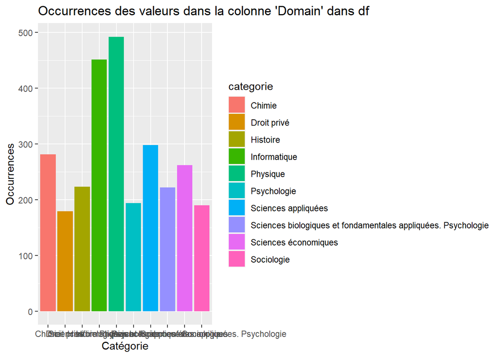

```r
occurrences <- table(df$Domain)
occurrences_df <- as.data.frame(occurrences)
names(occurrences_df) <- c("categorie", "occurrences")

occurrences_df %>%
  ggplot(aes(x = categorie, y = occurrences, fill = categorie)) +
  geom_bar(stat = "identity") +
  labs(title = "Occurrences des valeurs dans la colonne 'Domain' dans df",
       x = "Catégorie",
       y = "Occurrences")
```

Nous observons que les occurrences ne sont pas uniformément réparties, avec une supériorité de textes en Informatique et en Physique mais la distribution reste acceptable.

```r
cat("Nombre de valeurs de la colonne Direction : ", length(unique(df$Direction)), "\n")
```

```
## Nombre de valeurs de la colonne Direction :  2456
```

```r
cat("Nombre de valeurs de la colonne Statuts : ", length(unique(df$Statuts)), "\n")
```

```
## Nombre de valeurs de la colonne Statuts :  2
```

Nous voulons maintenant connaître la répartition et la fréquence des différents statuts au sein de notre dataset. Pour cela, nous créons un barplot qui va compter le nombre d’itérations dans chaque statut.

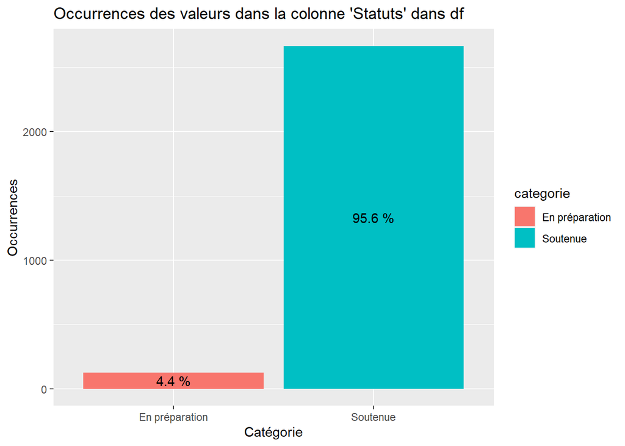

```r
occurrences <- table(df$Statuts)
occurrences_df <- as.data.frame(occurrences)
names(occurrences_df) <- c("categorie", "occurrences")

occurrences_df %>%
  ggplot(aes(x = categorie, y = occurrences, fill = categorie)) +
  geom_bar(stat = "identity") +
  geom_text(aes(label = paste(round(occurrences / nrow(df), 3) * 100, "%")),
            position = position_stack(vjust = 0.5)) +
  labs(title = "Occurrences des valeurs dans la colonne 'Statuts' dans df",
       x = "Catégorie",
       y = "Occurrences")
```

Nous pouvons clairement voir la supériorité de la catégorie ‘Soutenue’, qui compte 95,6% d’occurrences comparé à ‘En préparation’, qui n’en compte que 4,4%. Cette colonne ne sera donc pas très utile dans notre modèle.

###### 1.1.2 Prétraitement des données :

```r
str(df)
```

```
## 'data.frame':    2792 obs. of  9 variables:
##  $ Date       : chr  "1992-01-01" "2014-04-10" "1991-01-01" "2007-01-01" ...
##  $ URL        : chr  "https://www.theses.fr/1992REN10113" "https://www.theses.fr/2014STRAB002" "https://www.theses.fr/1991REN11001" "https://www.theses.fr/2007GRE10314" ...
##  $ Title      : chr  "ETUDE DE PROTEINES CORRESPONDANT A DES ARNm SPECIFIQUEMENT REGULES APRES LA FECONDATION CHEZ LE XENOPE" "Essays on eco-innovation" "Analyse des performances des filieres avicoles, role de l'organisation" "Le tris-dipicolinate de lanthanide : un complexe luminescent pour la r…
##  $ Author     : chr  "Jean-Pierre Tassan" "Serdal Ozusaglam" "Yunnan Shi" "Guillaume Pompidor" ...
##  $ Description: chr  "Notre travail a consiste a identifier la proteine codee par le clone cli. Ce cdna correspondant a un mrna speci"| __truncated__ "Le Chapitre 1 propose un survol de la littérature consacrée à l'éco-innovation. A la lumière des travaux passés"| __truncated__ "La crise actuelle…
##  $ Direction  : chr  "KATHERINE LE GUEILEC" "Robin Cowan" "Jean-François Audroing" "Richard Kahn" ...
##  $ IdDirection: chr  NA "052503720" "026695901" "061105570" ...
##  $ Statuts    : chr  "Soutenue" "Soutenue" "Soutenue" "Soutenue" ...
##  $ Domain     : chr  "Sciences biologiques et fondamentales appliquées. Psychologie" "Sciences économiques" "Sciences économiques" "Physique" ...
```

Nous commençons dans cette partie le prétraitement de nos données.

Tout d’abord, nous allons nettoyer le contenu de nos thèses en supprimant la ponctuation, les caractères spéciaux, les URL, les emojis et les mots vides. Pour cela, nous créons une fonction qui va les supprimer un par un.

```r
clean_text <- function(text) {
  text <- tolower(text)

  #supprime emojis
  text <- str_replace_all(text, "[\\x{10000}-\\x{1FFFF}]", "")

  #supprime ponctuation et caractères non-alphanumériques
  text <- str_replace_all(text, "[^a-zA-Z\\s]", " ")

  #supprime mots courts
  text <- str_split(text, "\\s+")
  text <- unlist(text)
  text <- text[str_length(text) > 2]

  #supprime stopwords
  stopwords_en <- stopwords("en")
  stopwords_fr <- stopwords("fr")
  stopwords_pattern <- paste0("\\b", paste(c(stopwords_en, stopwords_fr), collapse = "\\b|\\b"), "\\b")
  text <- str_replace_all(text, stopwords_pattern, "")

  #stemming
  text <- wordStem(text, language = "french")
  text <- wordStem(text, language = "english")

  preprocessed_text <- str_trim(paste(text, collapse = " "))

  return(preprocessed_text)
}
```

Nous appliquons notre fonction à notre dataset et plus précisément sur les colonnes ‘Description’ et ‘Title’.

```r
df <- df %>%
  mutate(Title = lapply(Title, clean_text))


df <- df %>%
  mutate(Description = lapply(Description, clean_text))
```

Nous supprimons les nouvelles valeurs vides.

```r
df <- na.omit(df)
df <- df %>%
  filter_all(all_vars(. != ""))
```

```r
cat("Nouvelles dimensions de df : ", dim(df), "\n")
```

```
## Nouvelles dimensions de df :  2416 9
```

Nous avons maintenant 2416 observations, contrairement aux précédentes 2792.

Nous procédons ensuite à transformer les descriptions de thèses doctorales en un nuage de mots. Cela va nous permettre d’identifier visuellement les termes les plus fréquents dans les thèses.

Le but est d’extraire et de visualiser les tendances dominantes dans notre dataset.

```r
corpus <- Corpus(VectorSource(df$Description))
corpus <- tm_map(corpus, content_transformer(tolower))
corpus <- tm_map(corpus, removePunctuation)
```

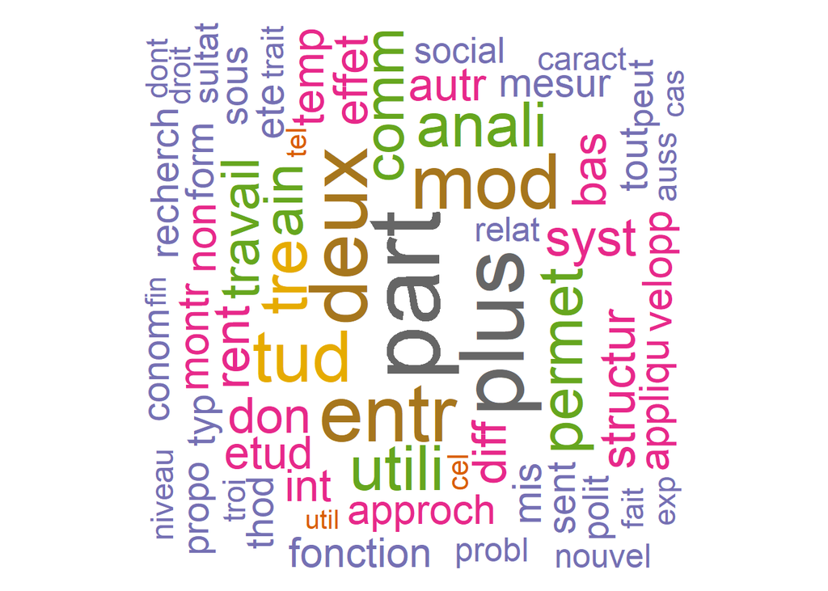

```r
tdm <- as.matrix(TermDocumentMatrix(corpus))

w <- sort(rowSums(tdm), decreasing = TRUE)
set.seed(222)
wordcloud(words = names(w),
          freq = w,
          max.words = 100,
          random.order = FALSE,
          min.freq = 5,
          colors = brewer.pal(8, "Dark2"),
          scale = c(5, 0.3),
          rot.per = 0.7)
```

Nous pouvons clairement observer que la taille varie significativement entre les mots les plus utilisés tels que “part”, “plus”, “entr”, “deux” et “anali”, qui font contraste avec des mots tels que “social”, “droit”, “niveau”, qui sont en plus petite taille.

Ces résultats sont cohérents puisque les mots qui sont plus grands sont des mots plus souvent utilisés dans des phrases structurées, tandis que les mots plus petits mais quand même bien présents dans notre dataset reflètent qu’il y a des corpus bien variés dans les thèses, comme le suggèrent : “droit”, “recherch”, “social”.

Nous voulons ensuite transformer les colonnes domain, direction puis status en facteurs ainsi que transformer en valeurs numériques les dates pour une exploitation plus facile.

On va maintenant convertir les étiquettes Domain, Direction, Status et Date en facteur pour qu’il soit dans un format plus adapté pour notre futur modèle.

```r
#transforme en facteur les colonnes domain, direction et statuts
df$Domain <- factor(df$Domain, levels = unique(df$Domain))
df$Direction <- as.numeric(factor(df$Direction,
                                  levels = c(unique(df$Direction)))) - 1
df$Statuts <- as.numeric(factor(df$Statuts, levels = c(unique(df$Statuts)))) - 1

#transforme en valeur numérique les dates
df$Date <- as.Date(df$Date)
df$Date <- as.numeric(df$Date - min(df$Date))

str(df)
```

```
## 'data.frame':    2416 obs. of  9 variables:
##  $ Date       : num  10691 2191 8035 13821 7305 ...
##  $ URL        : chr  "https://www.theses.fr/2014STRAB002" "https://www.theses.fr/1991REN11001" "https://www.theses.fr/2007GRE10314" "https://www.theses.fr/s359706" ...
##  $ Title      :List of 2416
##   ..$ : chr "essay eco innov"
##   ..$ : chr "anali  perform  filier avicol rol organi"
##   ..$ : chr "tris dipicolinat lanthanid complex luminesc  solut structur macromol cul biolog   thod sad mad"
##   ..$ : chr "cession det"
##   ..$ : chr "jool casam tat identi jool gal"
##   ..$ : chr "etud pilot  observ  chimioth rap oral construct  chel mesur observ tud  termin psychosoci"
##   ..$ : chr "claus exorbit droit commun dev cour cassat"
##   ..$ : chr "christiani cadr vi religi nord ouest dioc toul  origin fin xii cle"
##   ..$ : chr "magnet reson microscopi aplysi neuron studi neurotransmitt modul transport  respon stress"
##   ..$ : chr "mod lis diction branch  calcul temp cution pir cas"
##   ..$ : chr "bifurc   problem hydrodynam symetr plan spheriqu"
##   ..$ : chr "microscop electron tre haut resolu structur coeur  defaut  diam synthet"
##   ..$ : chr "mod lisat atomist product hydrog   lectrocatalyseur riv mos impact eau potentiel lectrochim   stabil activ"
##   ..$ : chr "jean lou nogaret valet duc epernon  vi polit"
##   ..$ : chr "imposit  revenus per   crivain compositeur tud compar aspect intern"
##   ..$ : chr "dichlorom thyl nation lacton riv sucr appliqu synth biomol cul"
##   ..$ : chr "caract risat nitrur lectriqu pos  pulv risat ioniqu activ appliqu micro lectron"
##   ..$ : chr "rifiqu automat cod syst aid abstract moir bas  typag"
##   ..$ : chr "utili polym inorgan oxyd  elabor composit architectur"
##   ..$ : chr "synth acoustico visuel parol  lection unit bimod"
##   ..$ : chr "etud optiqu etat normal  materi supraconducteur haut temperatur critiqu"
##   ..$ : chr "vi religi  cathol  ouest main loir vend epoqu revolutionnair"
##   ..$ : chr "solut  quation navi stok  diff renc fin axisym triqu"
##   ..$ : chr "real tim simul physic model toward hardwar  loop valid"
##   ..$ : chr "endog monnai sil ation dit apr adopt gim ciblag inflat"
##   ..$ : chr "approch bay sien tomograph micro ond appliqu imag canc sein"
##   ..$ : chr "contribu tud velopp techniqu gestion fen tre"
##   ..$ : chr "cycloisom risat catali   sel gallium  complex nhc gallium iii"
##   ..$ : chr "int gration financ europ enn fiscal  revenus capit"
##   ..$ : chr "recherch purif protein basiqu li adn chez cyanobact agmenellum aquadruplicatum   chloroplast spinaci oleac anal"| __truncated__
##   ..$ : chr "nord  delt nil vii xvi cle apr  sourc arab"
##   ..$ : chr "consolid  polit prudentiel europ fac interd pendanc  diff rent tier banqu"
##   ..$ : chr "concept ordonnanc  appliqu haut irr gul re  context paral lism grain fin"
##   ..$ : chr "utili nouveau tecteur nouvel mol cul scintil assoc  mesur  metteur alpha  scintal liquid alpha"
##   ..$ : chr "contr attaqu simpl pow anali efficac   appliqu cryptograph asym triqu algorithm implant"
##   ..$ : chr "thiqu silenc"
```

[output cut: 157 more lines]

```
##   ..$ : chr "ation uem  autor  tair craignent choc  tair commun   effet el asym triqu entr  pay objet   donc clarifi  effet "| __truncated__
##   ..$ : chr "emul concentr forment  structur analogu  mouss appel mouss biliquid  cas emul huil  eau ell  constitu cellul po"| __truncated__
##   ..$ : chr "couvr sujet  syst  trait don grand chel plus cis ment troi approch compl mentair concept syst  dir  faillanc se"| __truncated__
##   ..$ : chr "retropropag classiqu  reseau neuromimet requiert  echantillon entr sort apprentissag evolut etud    peut effect"| __truncated__
##   ..$ : chr "sent  thod anali concept orient objet syst  inform actif int  approch  mis uvr effect faibl couplag  compo logi"| __truncated__
##   ..$ : chr "probl transit post trol  objet occup  instanc alg rien afin repouss dat pui  serv trol re alg ri esp velopp  po"| __truncated__
##   ..$ : chr "caracterist  futur gener satellit conduis communaut spatial orient ver utili propulseur electr  moteur effet ha"| __truncated__
##   ..$ : chr "tud tent sai logiqu ration nom int gration conom gional afriqu  efforc pondr quelqu question fondament tel  pou"| __truncated__
##   .. [list output truncated]
##  $ Direction  : num  0 1 2 3 4 5 6 7 8 9 ...
##  $ IdDirection: chr  "052503720" "026695901" "061105570" "030073774" ...
##  $ Statuts    : num  0 0 0 1 0 0 0 0 0 0 ...
##  $ Domain     : Factor w/ 10 levels "Sciences économiques",..: 1 1 2 3 4 5 3 4 2 6 ...
##  - attr(*, "na.action")= 'omit' Named int [1:374] 1 7 9 12 24 25 29 35 39 41 ...
##   ..- attr(*, "names")= chr [1:374] "3" "23" "25" "39" ...
```

#### 1.2 TF-IDF :

Nous allons maintenant procéder à la vectorisation du texte en utilisant la méthode de la fréquence des termes et de la fréquence inverse du document. Pour cela, on utilise la librairie tm et sa fonction DocumentTermMatrix.

```r
#TF-IDF
corpus <- Corpus(VectorSource(df$Description))
corpus <- tm_map(corpus, content_transformer(tolower))
corpus <- tm_map(corpus, removePunctuation)
dtm <- DocumentTermMatrix(corpus)
empty_docs <- rowSums(as.matrix(dtm)) == 0
dtm <- dtm[!empty_docs, ]
df <- df[!empty_docs, ]
tfidf <- weightTfIdf(dtm)
tfidf <- as.matrix(tfidf)
tfidf_df <- as.data.frame(tfidf)

df <- cbind(df, tfidf_df)
df <- df[, -which(names(df) == "Description"), drop = FALSE]

cat("Nouvelles dimensions de df : ", dim(df), "\n")
```

```
## Nouvelles dimensions de df :  2416 18954
```

```r
df[, 1:20] %>%
  head() %>%
  kbl() %>%
  kable_styling(bootstrap_options = "striped", full_width = FALSE,
                position = "center")
```

| Date | URL | Title | Author | Direction | IdDirection | Statuts | Domain | accord | adopt | aid | ain | ajout | anali | appari | appel | attent | autr | barr | bien |
| --- | --- | --- | --- | --- | --- | --- | --- | --- | --- | --- | --- | --- | --- | --- | --- | --- | --- | --- | --- |
| 10691 | https://www.theses.fr/2014STRAB002 | essay eco innov | Serdal Ozusaglam | 0 | 052503720 | 0 | Sciences économiques | 0.0261416 | 0.1036503 | 0.0349763 | 0.0089032 | 0.0305031 | 0.0097023 | 0.0434564 | 0.0220515 | 0.0261416 | 0.0104514 | 0.0392681 | 0.0157398 |
| 2191 | https://www.theses.fr/1991REN11001 | anali perform filier avicol rol organi | Yunnan Shi | 1 | 026695901 | 0 | Sciences économiques | 0.0000000 | 0.0000000 | 0.0000000 | 0.0000000 | 0.0000000 | 0.0000000 | 0.0000000 | 0.0000000 | 0.0000000 | 0.0000000 | 0.0000000 | 0.0000000 |
| 8035 | https://www.theses.fr/2007GRE10314 | tris dipicolinat lanthanid complex luminesc solut structur macromol cul biolog thod sad mad | Guillaume Pompidor | 2 | 061105570 | 0 | Physique | 0.0000000 | 0.0000000 | 0.0000000 | 0.0000000 | 0.0000000 | 0.0000000 | 0.0000000 | 0.0000000 | 0.0000000 | 0.0000000 | 0.0000000 | 0.0000000 |
| 13821 | https://www.theses.fr/s359706 | cession det | Nicolas Chapalin-Mecirdi | 3 | 030073774 | 1 | Droit privé | 0.0000000 | 0.0000000 | 0.0000000 | 0.0155351 | 0.0000000 | 0.0000000 | 0.0000000 | 0.0000000 | 0.0000000 | 0.0000000 | 0.0000000 | 0.0000000 |
| 7305 | https://www.theses.fr/2005PA070036 | jool casam tat identi jool gal | Séverine Awenengo Dalberto | 4 | 055061915 | 0 | Histoire | 0.0000000 | 0.0000000 | 0.0000000 | 0.0000000 | 0.0000000 | 0.0128612 | 0.0000000 | 0.0000000 | 0.0000000 | 0.0277084 | 0.0000000 | 0.0000000 |
| 10535 | https://www.theses.fr/2013LORR0326 | etud pilot observ chimioth rap oral construct chel mesur observ tud termin psychosoci | Frédéric Peter | 5 | 075974479 | 0 | Psychologie | 0.0000000 | 0.0000000 | 0.0000000 | 0.0000000 | 0.0000000 | 0.0000000 | 0.0000000 | 0.0000000 | 0.0000000 | 0.0000000 | 0.0000000 | 0.0000000 |

Nous avons transformé la colonne “Description” en un large ensemble de colonnes, avec une colonne pour chaque terme présent dans les descriptions des thèses.

Lorsqu’un terme apparaît dans la colonne “Description”, la colonne correspondante pour cette ligne affiche la fréquence du terme calculée avec la méthode TF-IDF. Dans le cas contraire, cette colonne aura la valeur 0.

Cette représentation crée un espace de caractéristiques numériques qui reflète l’importance de chaque mot dans le contexte du corpus.

## 2. Extraction de caractéristiques (Feature Extraction) :

Nous allons appliquer l’analyse LDA pour extraire 20 topics principaux des descriptions de thèses, et nous enrichissons le dataframe avec ces informations, ce qui va nous permettre d’avoir une analyse thématique des données.

```r
#ajout de topics qui reviennent le plus dans les descriptions de thèses
library(topicmodels)
str(dtm)
```

```
## List of 6
##  $ i       : int [1:231080] 1 1 1 1 1 1 1 1 1 1 ...
##  $ j       : int [1:231080] 1 2 3 4 5 6 7 8 9 10 ...
##  $ v       : num [1:231080] 1 4 2 1 1 1 1 1 1 1 ...
##  $ nrow    : int 2416
##  $ ncol    : int 18946
##  $ dimnames:List of 2
##   ..$ Docs : chr [1:2416] "1" "2" "3" "4" ...
##   ..$ Terms: chr [1:18946] "accord" "adopt" "aid" "ain" ...
##  - attr(*, "class")= chr [1:2] "DocumentTermMatrix" "simple_triplet_matrix"
##  - attr(*, "weighting")= chr [1:2] "term frequency" "tf"
```

```r
model <- LDA(dtm, k = 20)
Topic <- as.matrix(topics(model))
df <- cbind(df, Topic)

terms(model)
```

```
##  Topic 1  Topic 2  Topic 3  Topic 4  Topic 5  Topic 6  Topic 7  Topic 8
##    "cle"   "part"    "tud"   "part"    "mod"   "thod"  "conom"   "plus"
##  Topic 9 Topic 10 Topic 11 Topic 12 Topic 13 Topic 14 Topic 15 Topic 16
##   "seau"  "graph"  "droit"    "tud"   "etud"   "etud"    "ete"    "tud"
## Topic 17 Topic 18 Topic 19 Topic 20
## "social" "econom"  "synth" "system"
```

Après l’application du code LDA, nous avons une structure de données textuelles qui contient 231 080 occurrences non nulles. Cela nous montre la diversité considérable dans l’utilisation des termes à travers les 2416 documents étudiés.

```r
str(df$Topic)
```

```
##  int [1:2416] 7 18 16 11 2 3 11 1 12 9 ...
```

```r
length(unique(df$Topic))
```

```
## [1] 20
```

Nous observons que les 2416 textes ont bien été attribués à des topics, et qu’il y a bien 20 topics distincts comme on l’avait défini. L’analyse LDA a bien partitionné les thèses en 20 groupes différents selon leur contenu sémantique.

```r
top_topics <- df %>%
  group_by(Domain, Topic) %>%
  summarize(count = n()) %>%
  arrange(desc(count)) %>%
  group_by(Domain) %>%
  slice_head(n = 5)
top_topics
```

```
## # A tibble: 50 × 3
## # Groups:   Domain [10]
##    Domain               Topic count
##    <fct>                <int> <int>
##  1 Sciences économiques     7   150
##  2 Sciences économiques    18    36
##  3 Sciences économiques    17    18
##  4 Sciences économiques     8     8
##  5 Sciences économiques     3     6
##  6 Physique                12   149
##  7 Physique                13    89
##  8 Physique                14    65
##  9 Physique                 6    30
## 10 Physique                20    21
## # ℹ 40 more rows
```

Nous appliquons un filtre qui identifie les cinq topics les plus fréquents pour chaque domaine d’étude dans notre dataframe.

On peut voir que les topics les plus fréquents changent selon le domaine ce qui nous laisse penser que cela va permettre à notre modèle de classification final d’être plus précis, car il possède maintenant plus d’informations.

## 3. Réduction de la dimensionnalité :

Nous avons à présent de nombreuses colonnes, ce qui va augmenter significativement le temps de compilation de notre modèle.

C’est pourquoi nous allons éliminer certaines colonnes moins pertinentes pour l’analyse, comme “Date”, “URL”, “Title”, “Author”, “IdDirection”, “Direction”, “Status” et “Topic”.

Ensuite, nous enlevons les valeurs qui sont presque constantes. Dans notre cas, les valeurs ayant 5 valeurs uniques ou moins, puisque ces informations importent peu pour les analyses futures.

```r
#garde que certaines colonnes
df_LDA <- subset(df, select = -c(Date, URL, Title, Author, IdDirection, Direction, Statuts, Topic))

#identifier colonnes proches d'être  constantes
constant_cols <- apply(df_LDA, 2, function(x) length(unique(x)) <= 5)
#les supprimer
df_LDA <- df_LDA[, !constant_cols]

cat("Dimensions de df_LDA : ", dim(df_LDA), "\n")
```

```
## Dimensions de df_LDA :  2416 4773
```

```r
df_LDA[, 1:20] %>%
  head() %>%
  kbl() %>%
  kable_styling(bootstrap_options = "striped", full_width = FALSE,
                position = "center")
```

| Domain | accord | adopt | aid | ain | ajout | anali | appari | appel | attent | autr | barr | bien | chapitr | cifiqu | cis | cision | coc | comm | communautair |
| --- | --- | --- | --- | --- | --- | --- | --- | --- | --- | --- | --- | --- | --- | --- | --- | --- | --- | --- | --- |
| Sciences économiques | 0.0261416 | 0.1036503 | 0.0349763 | 0.0089032 | 0.0305031 | 0.0097023 | 0.0434564 | 0.0220515 | 0.0261416 | 0.0104514 | 0.0392681 | 0.0157398 | 0.146397 | 0.0436329 | 0.0236183 | 0.0256896 | 0.0836367 | 0.0194266 | 0.038909 |
| Sciences économiques | 0.0000000 | 0.0000000 | 0.0000000 | 0.0000000 | 0.0000000 | 0.0000000 | 0.0000000 | 0.0000000 | 0.0000000 | 0.0000000 | 0.0000000 | 0.0000000 | 0.000000 | 0.0000000 | 0.0000000 | 0.0000000 | 0.0000000 | 0.0000000 | 0.000000 |
| Physique | 0.0000000 | 0.0000000 | 0.0000000 | 0.0000000 | 0.0000000 | 0.0000000 | 0.0000000 | 0.0000000 | 0.0000000 | 0.0000000 | 0.0000000 | 0.0000000 | 0.000000 | 0.0000000 | 0.0000000 | 0.0000000 | 0.0000000 | 0.0000000 | 0.000000 |
| Droit privé | 0.0000000 | 0.0000000 | 0.0000000 | 0.0155351 | 0.0000000 | 0.0000000 | 0.0000000 | 0.0000000 | 0.0000000 | 0.0000000 | 0.0000000 | 0.0000000 | 0.000000 | 0.0000000 | 0.0412116 | 0.0000000 | 0.0000000 | 0.0169487 | 0.000000 |
| Histoire | 0.0000000 | 0.0000000 | 0.0000000 | 0.0000000 | 0.0000000 | 0.0128612 | 0.0000000 | 0.0000000 | 0.0000000 | 0.0277084 | 0.0000000 | 0.0000000 | 0.000000 | 0.0000000 | 0.0000000 | 0.0000000 | 0.0000000 | 0.0000000 | 0.000000 |
| Psychologie | 0.0000000 | 0.0000000 | 0.0000000 | 0.0000000 | 0.0000000 | 0.0000000 | 0.0000000 | 0.0000000 | 0.0000000 | 0.0000000 | 0.0000000 | 0.0000000 | 0.000000 | 0.0253783 | 0.0000000 | 0.0000000 | 0.0000000 | 0.0225983 | 0.000000 |

Avant cette modification, nous avions une représentation de df qui avait une dimension : 2416 x 18954.

Après traitement, nous avons df_LDA avec une dimension : 2416 x 4773.

Avant de faire notre analyse discriminante linéaire (LDA), nous voulons connaître la structure de notre dataset :

```r
P <- ncol(df_LDA) - 1
P
```

```
## [1] 4772
```

```r
N <- nrow(df_LDA)
N
```

```
## [1] 2416
```

```r
K <- length(unique(df_LDA$Domain))
K
```

```
## [1] 10
```

```r
G <- colMeans(df_LDA[, -which(names(df_LDA) == "Domain"), drop = FALSE])
```

Nous avons N = 2416, correspondant au nombre d’observations disponibles pour les calculs, P = 4772, qui est le nombre de variables explicatives, et K = 10, qui est le nombre de classes que l’on devra prédire.

Pour lancer l’analyse discriminante, nous utiliserons le modèle lda du package “MASS”. Ce modèle prend en paramètres une formule qui dit par rapport à quelles colonnes on veut prédire nos classes. Nous voulons prédire la colonne Domain par rapport à toutes les autres colonnes, d’où l’utilisation de “.” qui dit à notre modèle d’utiliser toutes les colonnes de notre dataset.

Nous mettons en commentaires les résumés de notre modèle car nous avons plus de 4000 colonnes ce qui rendrait la sortie très longue et illisible.

```r
#LDA
mLda <- lda(Domain ~ ., data = df_LDA)
# mLda
```

On affiche quelques caractéristiques de notre modèle, telles que les constantes des fonctions canoniques ou les moyennes conditionnelles :

```r
# # liste des propriétés de l’objet
# attributes(mLda)
# #a distribution relative des classes
# mLda$prior
# # distribution absolue
# mLda$counts
# # moyennes des variables conditionnellement aux classes
# mLda$means
# # matrice des coefficients des fonctions discriminantes
# mLda$scaling
# # libéllés des classes
# mLda$lev
# Constantes des fonctions canoniques
const_ <- apply(mLda$scaling, 2, function(v) {- sum(v * G)})
const_
```

```
##         LD1         LD2         LD3         LD4         LD5         LD6
##  2.68744690 -0.15638096 -0.08386607 -0.26116341  0.45296589  0.04728382
##         LD7         LD8         LD9
##  0.01416650  0.06040895 -0.13283320
```

```r
# Moyennes conditionnelles
cond_xb <- sapply(1:ncol(mLda$scaling), function(j)
                  {sapply(mLda$lev,
                  function(niveau){sum(mLda$scaling[, j] * mLda$means[niveau, ]) + const_[j]})
                  })
colnames(cond_xb) <- paste("LD",1:ncol(mLda$scaling), sep = "")
rownames(cond_xb) <- mLda$lev
cond_xb
```

```
##                                                                      LD1
## Sciences économiques                                           -2.933287
## Physique                                                       33.041333
## Droit privé                                                    -3.492363
## Histoire                                                       -2.814942
## Psychologie                                                    -4.835115
## Informatique                                                  -36.214427
## Chimie                                                         14.712077
## Sciences appliquées                                             2.206829
## Sciences biologiques et fondamentales appliquées. Psychologie   7.798270
## Sociologie                                                     -5.481826
##                                                                      LD2
## Sciences économiques                                          -2.6963642
## Physique                                                       1.6566817
## Droit privé                                                   -3.6508116
## Histoire                                                      -4.9491563
## Psychologie                                                   -1.7435940
## Informatique                                                   3.0362751
## Chimie                                                         2.5710047
## Sciences appliquées                                            2.4914466
## Sciences biologiques et fondamentales appliquées. Psychologie  0.8246378
## Sociologie                                                    -4.1842562
##                                                                      LD3
## Sciences économiques                                           0.2272008
## Physique                                                       0.8225592
## Droit privé                                                    5.8810497
## Histoire                                                      -0.7400012
## Psychologie                                                   -3.0490468
## Informatique                                                   0.4616762
## Chimie                                                        -0.3016878
## Sciences appliquées                                            0.3189301
## Sciences biologiques et fondamentales appliquées. Psychologie -3.8521398
## Sociologie                                                    -1.7452445
##                                                                      LD4
## Sciences économiques                                          -0.3279616
## Physique                                                       1.8135968
## Droit privé                                                   -3.2656633
## Histoire                                                       1.9257670
## Psychologie                                                   -0.1292906
## Informatique                                                   0.7819828
```

[output cut: 44 more lines]

```
## Chimie                                                         0.34745400
## Sciences appliquées                                            1.16135623
## Sciences biologiques et fondamentales appliquées. Psychologie -0.31755952
## Sociologie                                                     4.34452811
##                                                                       LD9
## Sciences économiques                                          -0.14415254
## Physique                                                       1.08120139
## Droit privé                                                    0.02375288
## Histoire                                                      -0.68720823
## Psychologie                                                   -0.54649723
## Informatique                                                   0.93889975
## Chimie                                                         0.32121171
## Sciences appliquées                                           -3.97612580
## Sciences biologiques et fondamentales appliquées. Psychologie  0.50654053
## Sociologie                                                     1.10284104
```

```r
# # Coefficients des fonctions de classement déduits des fonctions canoniques
# coef_ <- sapply(mLda$lev, function(niveau)
#                 {rowSums(sapply(1:ncol(mLda$scaling),
#                                 function(j) {mLda$scaling[, j] * cond_xb[niveau, j]}))
#                 })
# coef_
# # Intercept des fonctions de classement
# intercept_ <- sapply(mLda$lev, function(niveau)
#                      {sum(mapply(prod, const_, cond_xb[niveau,])) - 0.5 * sum(cond_xb[niveau, ]^2) + log(mLda$prior[niveau])})
# names(intercept_) <- levels(df$sentiment)
# intercept_
```

```r
#récupération des données après la réduction de dimensionalité
LDA_dimensions <- predict(mLda)$x
attributes(LDA_dimensions)$dim
```

```
## [1] 2416    9
```

```r
attributes(LDA_dimensions)$dimnames[[2]]
```

```
## [1] "LD1" "LD2" "LD3" "LD4" "LD5" "LD6" "LD7" "LD8" "LD9"
```

```r
head(LDA_dimensions)
```

```
##         LD1        LD2        LD3        LD4       LD5         LD6         LD7
## 1 -2.891972 -2.1209263  1.5664318 -1.4760699 -1.390946  5.22020117 -0.07198954
## 2 -2.875341 -0.7455112 -0.6031833 -1.2268506 -1.553306  2.91933061 -0.02747724
## 3 33.198854  2.6728201  1.4279217  0.4073745  1.224841 -0.06955379 -1.04621131
## 4 -3.500878 -4.2565713  6.5471374 -3.5956605  0.191338 -1.75971261  0.75697450
## 5 -2.801871 -4.5001573 -1.4746782  1.6456211  4.312655  0.36583806  1.17871225
## 6 -4.833393 -0.7648421 -1.8686248  0.2575089 -4.261814 -3.43268410 -1.65318895
##          LD8        LD9
## 1  1.5771401 -0.8439585
## 2 -1.0680187  1.0470535
## 3  0.2553388  2.2377113
## 4 -0.1046684  0.6370649
## 5 -1.5029294 -0.5477164
## 6 -1.5840752 -1.1864046
```

Nous affichons les plus gros coefficients pour chaque LDA.

```r
for (i in seq_len(ncol(mLda$scaling))) {
  coefficients_col <- mLda$scaling[, i]
  sorted_indices <- order(-abs(coefficients_col))
  top_10_coefficients <- mLda$scaling[sorted_indices[1:10], ]

  cat("LDA", i, ": \n")
  cat("Les 10 plus gros coefficients sont: \n\n")
  print(top_10_coefficients)
}
```

```
## LDA 1 :
## Les 10 plus gros coefficients sont:
##
##                   LD1        LD2        LD3        LD4       LD5         LD6
## monstrateur  258.1877 -16.061241  -2.527165  8.1468614 20.284377  -3.1652655
## flexiv      -254.3865   7.482114 -13.275402  4.5536624 14.736585  11.8554789
## decrivon    -207.2483   6.835004   5.632848  6.7377043  7.750362   0.6905836
## simplic      193.6957  -4.424335   3.613262  6.0902353 -7.783425  14.9685392
## poussent     191.8691  -2.423891  -0.362714 -0.8615022  2.646553  -0.9840734
## transput     181.8524 -18.788590   1.703060 -4.2940000  3.420156   1.3728123
## repouss      180.0137  -4.309461   1.131287  6.4460487  5.531601  -0.4367475
## supervi     -171.8732   4.479080  -3.207094  5.0082892 10.373658   2.2563151
## apprend     -171.3801  14.185442  -6.060127 -9.8628178 -9.973930 -14.5844227
## verrouillag  167.9192 -19.857209   2.434125 -2.7668054  1.795770 -10.7008065
##                    LD7        LD8        LD9
## monstrateur  -8.483369  0.4829325 -10.201122
## flexiv        4.570790 -3.7704649   2.284815
## decrivon    -10.982438 -3.0022404  -3.247277
## simplic      -9.691110 -1.2062615   7.150819
## poussent      4.644389  9.0317279  -7.608323
## transput      4.422213  5.4026501 -14.221225
## repouss       3.055947  0.2615043  -1.570854
## supervi      -2.489607 12.5277985   3.137641
## apprend     -16.375865  1.0113986 -10.798665
## verrouillag   5.270339 10.3907667  -7.153959
## LDA 2 :
## Les 10 plus gros coefficients sont:
##
##                   LD1       LD2         LD3        LD4        LD5        LD6
## supposon     27.25066  24.46867   2.6144904  -2.062207 -18.089470   7.657201
## substitut    77.29776 -24.24143   2.3881834  19.578474  13.906003   9.234459
## solvent     -93.08535  22.93093   8.4266332  -5.083552   4.347418  -8.912465
## perd         27.97592 -21.37544  -3.5606915   1.885222   7.436305   2.217749
## immen       -20.30156 -20.13461 -12.2221897   9.398731  -1.962665   4.410187
## maintient    62.84365 -19.88175   0.1714572 -31.632383  -2.696516  -2.719904
## verrouillag 167.91920 -19.85721   2.4341250  -2.766805   1.795770 -10.700806
## transpo     151.80733 -19.41705   3.0284726 -15.086692  -7.813955   5.866639
## transput    181.85235 -18.78859   1.7030601  -4.294000   3.420156   1.372812
## propic       50.59029 -18.74789  10.1097368   2.261832  -2.215615  -6.248890
##                    LD7        LD8         LD9
```

[output cut: 170 more lines]

```
## cisiv      36.74352  4.7656597  7.608633 -2.118589 -6.660771 16.790831
## pan       112.99554 -3.4397900  1.880849 -8.263287  3.922029 -2.877947
## allong     68.63692 -0.6148816 -9.508648 -1.975881  2.081573  3.274662
## exempt     37.36222 -5.6975048  7.375769  2.683215 -2.337221 -2.358279
##                  LD7         LD8       LD9
## varient   -8.6325901  -1.1766748 -22.26967
## appri      6.9592889 -11.2303605  19.75799
## souffrent 12.2224852  -4.0707356  18.76434
## arit       5.6039263  -5.9598220  18.64111
## soutienn  -0.6666215  -9.8315899 -18.62164
## initiali   7.0564601   0.9870408 -17.42265
## cisiv      0.9062812  12.4023034 -17.41264
## pan        7.0458758   0.5261178  16.49876
## allong    16.4296846  -3.0331498  16.44145
## exempt    -3.2475501  -4.2278742 -15.80588
```

On combine les dimensions issues de l’analyse LDA avec un sous-ensemble de notre dataset df, qui inclut les colonnes “Date”, “Topic” et “Domain”, pour obtenir un dataset df_bayes plus complète.

```r
df_bayes <- cbind(LDA_dimensions, subset(df, select = c(Date, Topic, Domain)))

str(df_bayes)
```

```
## 'data.frame':    2416 obs. of  12 variables:
##  $ LD1   : num  -2.89 -2.88 33.2 -3.5 -2.8 ...
##  $ LD2   : num  -2.121 -0.746 2.673 -4.257 -4.5 ...
##  $ LD3   : num  1.566 -0.603 1.428 6.547 -1.475 ...
##  $ LD4   : num  -1.476 -1.227 0.407 -3.596 1.646 ...
##  $ LD5   : num  -1.391 -1.553 1.225 0.191 4.313 ...
##  $ LD6   : num  5.2202 2.9193 -0.0696 -1.7597 0.3658 ...
##  $ LD7   : num  -0.072 -0.0275 -1.0462 0.757 1.1787 ...
##  $ LD8   : num  1.577 -1.068 0.255 -0.105 -1.503 ...
##  $ LD9   : num  -0.844 1.047 2.238 0.637 -0.548 ...
##  $ Date  : num  10691 2191 8035 13821 7305 ...
##  $ Topic : int  7 18 16 11 2 3 11 1 12 9 ...
##  $ Domain: Factor w/ 10 levels "Sciences économiques",..: 1 1 2 3 4 5 3 4 2 6 ...
```

```r
cat("Dimensions de df_bayes : ", dim(df_bayes), "\n")
```

```
## Dimensions de df_bayes :  2416 12
```

```r
df_bayes %>%
  head() %>%
  kbl() %>%
  kable_styling(bootstrap_options = "striped", full_width = FALSE,
                position = "center")
```

| LD1 | LD2 | LD3 | LD4 | LD5 | LD6 | LD7 | LD8 | LD9 | Date | Topic | Domain |
| --- | --- | --- | --- | --- | --- | --- | --- | --- | --- | --- | --- |
| -2.891972 | -2.1209263 | 1.5664318 | -1.4760699 | -1.390946 | 5.2202012 | -0.0719895 | 1.5771401 | -0.8439585 | 10691 | 7 | Sciences économiques |
| -2.875341 | -0.7455112 | -0.6031833 | -1.2268506 | -1.553306 | 2.9193306 | -0.0274772 | -1.0680187 | 1.0470535 | 2191 | 18 | Sciences économiques |
| 33.198854 | 2.6728201 | 1.4279217 | 0.4073745 | 1.224840 | -0.0695538 | -1.0462113 | 0.2553388 | 2.2377113 | 8035 | 16 | Physique |
| -3.500878 | -4.2565713 | 6.5471374 | -3.5956605 | 0.191338 | -1.7597126 | 0.7569745 | -0.1046684 | 0.6370649 | 13821 | 11 | Droit privé |
| -2.801871 | -4.5001573 | -1.4746782 | 1.6456211 | 4.312655 | 0.3658381 | 1.1787122 | -1.5029294 | -0.5477164 | 7305 | 2 | Histoire |
| -4.833393 | -0.7648421 | -1.8686248 | 0.2575089 | -4.261814 | -3.4326841 | -1.6531889 | -1.5840752 | -1.1864046 | 10535 | 3 | Psychologie |

## 4. Classification bayésienne :

La classification bayésienne repose sur le théorème de Bayes, et nous allons l’utiliser pour prédire la catégorie d’un nouvel échantillon. Ce théorème calcule la probabilité qu’un échantillon appartienne à une classe donnée.

Dans notre contexte d’analyse des descriptions de thèses doctorales, nous utilisons cette méthode pour sa capacité à gérer la diversité textuelle et à intégrer des connaissances préalables sur les distributions des domaines.

```r
#séparation des données en un dataset d'entrainement et de test
X <- as.matrix(df_bayes[, -which(names(df_bayes) == "Domain"), drop = FALSE])
y <- df_bayes$Domain

cat("Dimensions de X : ", dim(X), "\n")
```

```
## Dimensions de X :  2416 11
```

```r
n <- nrow(df_bayes)
index <- sample(1:n, 0.8 * n)

X_train <- X[index, ]
y_train <- y[index]
X_test <- X[-index, ]
y_test <- y[-index]

cat("Dimensions de X_train : ", dim(X_train), "\n")
```

```
## Dimensions de X_train :  1932 11
```

```r
cat("Dimensions de X_test : ", dim(X_test), "\n")
```

```
## Dimensions de X_test :  484 11
```

```r
y_train %>%
  head() %>%
  kbl() %>%
  kable_styling(bootstrap_options = "striped", full_width = FALSE,
                position = "center")
```

| x |
| --- |
| Sociologie |
| Histoire |
| Sciences économiques |
| Sociologie |
| Chimie |
| Physique |

Nous entraînons le modèle bayésien sur nos données d’entraînement.

```r
model <- naiveBayes(X_train, y_train)
print(model)
```

```
##
## Naive Bayes Classifier for Discrete Predictors
##
## Call:
## naiveBayes.default(x = X_train, y = y_train)
##
## A-priori probabilities:
## y_train
##                                          Sciences économiques
##                                                    0.09730849
##                                                      Physique
##                                                    0.17132505
##                                                   Droit privé
##                                                    0.07349896
##                                                      Histoire
##                                                    0.08540373
##                                                   Psychologie
##                                                    0.07401656
##                                                  Informatique
##                                                    0.17184265
##                                                        Chimie
##                                                    0.09782609
##                                           Sciences appliquées
##                                                    0.09989648
## Sciences biologiques et fondamentales appliquées. Psychologie
##                                                    0.06055901
##                                                    Sociologie
##                                                    0.06832298
##
## Conditional probabilities:
##                                                                LD1
## y_train                                                               [,1]
##   Sciences économiques                                           -2.931770
##   Physique                                                       33.020234
##   Droit privé                                                    -3.492194
##   Histoire                                                       -2.815446
##   Psychologie                                                    -4.834285
##   Informatique                                                  -36.191834
##   Chimie                                                         14.711884
##   Sciences appliquées                                             2.208067
```

[output cut: 249 more lines]

```
##   Sciences appliquées                                           14.523316
##   Sciences biologiques et fondamentales appliquées. Psychologie 14.102564
##   Sociologie                                                    14.787879
##                                                                Topic
## y_train                                                             [,2]
##   Sciences économiques                                          4.808768
##   Physique                                                      3.527128
##   Droit privé                                                   3.135950
##   Histoire                                                      7.733576
##   Psychologie                                                   6.469226
##   Informatique                                                  4.244429
##   Chimie                                                        3.854956
##   Sciences appliquées                                           5.404543
##   Sciences biologiques et fondamentales appliquées. Psychologie 4.119727
##   Sociologie                                                    5.059992
```

Réalisation des prédictions du modèle sur nos données de test.

```r
predictions <- predict(model, X_test)

predictions
```

```
##   [1] Physique
##   [2] Histoire
##   [3] Physique
##   [4] Informatique
##   [5] Physique
##   [6] Chimie
##   [7] Informatique
##   [8] Physique
##   [9] Physique
##  [10] Physique
##  [11] Histoire
##  [12] Sciences biologiques et fondamentales appliquées. Psychologie
##  [13] Droit privé
##  [14] Droit privé
##  [15] Sociologie
```

[output cut: 470 more lines]

Les prédictions du modèle bayésien montrent une distribution variée des domaines d’étude pour les thèses.

De même, la présence de domaines spécialisés tels que “Sciences biologiques et fondamentales appliquées. Psychologie”, “Chimie” et “Droit privé” montre la capacité du modèle à prédire des domaines moins courants.

## 5. Performance Evaluation :

Nous allons maintenant afficher les métriques du modèle en plus d’afficher la fiabilité de celui-ci.

```r
confusion_matrix <- confusionMatrix(predictions, y_test)

accuracy <- confusion_matrix$overall["Accuracy"]
mesure <- confusion_matrix$byClass[, c("Precision", "Recall", "F1")]

cat("Exactitude:", accuracy, "\n")
```

```
## Exactitude: 0.981405
```

```r
mesure %>%
  kbl() %>%
  kable_styling(bootstrap_options = "striped", full_width = FALSE,
                position = "center")
```

|  | Precision | Recall | F1 |
| --- | --- | --- | --- |
| Class: Sciences économiques | 0.9333333 | 1.0000000 | 0.9655172 |
| Class: Physique | 1.0000000 | 0.9761905 | 0.9879518 |
| Class: Droit privé | 0.9523810 | 1.0000000 | 0.9756098 |
| Class: Histoire | 1.0000000 | 0.9736842 | 0.9866667 |
| Class: Psychologie | 1.0000000 | 0.9615385 | 0.9803922 |
| Class: Informatique | 1.0000000 | 0.9777778 | 0.9887640 |
| Class: Chimie | 0.9811321 | 1.0000000 | 0.9904762 |
| Class: Sciences appliquées | 0.9534884 | 1.0000000 | 0.9761905 |
| Class: Sciences biologiques et fondamentales appliquées. Psychologie | 0.9677419 | 0.9677419 | 0.9677419 |
| Class: Sociologie | 1.0000000 | 0.9565217 | 0.9777778 |

Les autres domaines ont également été bien prédits la grande majorité du temps, avec une précision supérieure à 95% pour la plupart.

Le score F1, qui combine précision et rappel, est également élevé pour toutes les classes, ce qui suggère un bon équilibre entre les deux métriques et une performance robuste du modèle.

```r
#matrice de confusion de notre modèle bayésien
matrice <- confusion_matrix$table

matrice %>%
  kbl() %>%
  kable_styling(bootstrap_options = "striped", full_width = FALSE,
                position = "center")
```

|  | Sciences économiques | Physique | Droit privé | Histoire | Psychologie | Informatique | Chimie | Sciences appliquées | Sciences biologiques et fondamentales appliquées. Psychologie | Sociologie |
| --- | --- | --- | --- | --- | --- | --- | --- | --- | --- | --- |
| Sciences économiques | 56 | 1 | 0 | 0 | 0 | 0 | 0 | 0 | 1 | 2 |
| Physique | 0 | 82 | 0 | 0 | 0 | 0 | 0 | 0 | 0 | 0 |
| Droit privé | 0 | 0 | 20 | 1 | 0 | 0 | 0 | 0 | 0 | 0 |
| Histoire | 0 | 0 | 0 | 37 | 0 | 0 | 0 | 0 | 0 | 0 |
| Psychologie | 0 | 0 | 0 | 0 | 25 | 0 | 0 | 0 | 0 | 0 |
| Informatique | 0 | 0 | 0 | 0 | 0 | 88 | 0 | 0 | 0 | 0 |
| Chimie | 0 | 1 | 0 | 0 | 0 | 0 | 52 | 0 | 0 | 0 |
| Sciences appliquées | 0 | 0 | 0 | 0 | 0 | 2 | 0 | 41 | 0 | 0 |
| Sciences biologiques et fondamentales appliquées. Psychologie | 0 | 0 | 0 | 0 | 1 | 0 | 0 | 0 | 30 | 0 |
| Sociologie | 0 | 0 | 0 | 0 | 0 | 0 | 0 | 0 | 0 | 44 |

La matrice de confusion de notre modèle bayésien montre que la classification a été correctement réalisée, avec la plupart des thèses dans leur domaine respectif.

## 6. Conclusion :

Pour conclure, nous sommes passés d’un dataset original de 539 597 échantillons à 15 000, puis finalement à 2416 après nettoyage et élimination des valeurs vides ou incomplètes.

Ensuite, nous avons transformé des descriptions textuelles en caractéristiques numériques via TF-IDF. Cela nous a permis de réduire la dimensionnalité des données et de les structurer de manière à maximiser l’efficacité du modèle bayésien.

Enfin, la matrice de confusion a révélé une forte capacité de classification avec une précision élevée dans tous les domaines. Cela confirme que les modifications que nous avons apportées au dataset ont été bénéfiques pour que notre modèle soit efficace.

Pour améliorer notre modèle, nous pouvons augmenter la quantité de données afin qu’il soit capable de mieux généraliser, ou analyser les erreurs commises par le modèle et adapter l’entraînement en conséquence.